# Análisis de datos ómicos - PEC 2

Emilio Alarcón Martín

14 de junio, 2020

# 1 Abstract

En este trabajo se lleva a cabo un análisis estadístico a partir de información de las muestras de un estudio obtenido del repositorio GTEx. Este repositorio contiene datos de múltiples tipos en un total de 54 tejidos. Nos centraremos en los datos de expresión (RNA-seq) pertenecientes a un análisis del tiroides según tipo de infiltración:

- Not infiltrated tissues (NIT)
- Small focal infiltrates (SFI)
- Extensive lymphoid infiltrates (ELI)

# 2 Objetivos

El principal objetivo de este trabajo es obtener un listado de genes que que se expresan más ampliamente diferenciados en tiroides, generar una lista de los más diferenciados (ordenados por p-valor) y se muestran las vías metabólicas en los que dichos genes se encuentran implicados.

# 3 Materiales y Métodos

## 3.1 Datos

```r
> print(head(targets))
```

```
  Experiment SRA_Sample              Sample_Name Grupo_analisis body_site
1  SRX567480  SRS626942 GTEX-111CU-0226-SM-5GZXC              1   Thyroid
2  SRX615964  SRS644174 GTEX-111FC-1026-SM-5GZX1              1   Thyroid
3  SRX563960  SRS625636 GTEX-111VG-0526-SM-5N9BW              3   Thyroid
4  SRX564185  SRS625665 GTEX-111YS-0726-SM-5GZY8              1   Thyroid
5  SRX559141  SRS624025 GTEX-1122O-0226-SM-5N9DA              1   Thyroid
6  SRX561718  SRS625313 GTEX-1128S-0126-SM-5H12S              1   Thyroid
         molecular_data_type    sex Group ShortName
1 Allele-Specific Expression   male   NIT 111CU_NIT
2              RNA Seq (NGS)   male   NIT 111FC_NIT
3              RNA Seq (NGS)   male   ELI 111VG_ELI
4 Allele-Specific Expression   male   NIT 111YS_NIT
5              RNA Seq (NGS) female   NIT 1122O_NIT
6 Allele-Specific Expression female   NIT 1128S_NIT
```

```r
> print(counts[1:10,1:2])
```

```
                   X GTEX.111CU.0226.SM.5GZXC
1  ENSG00000223972.4                        7
2  ENSG00000227232.4                      401
3  ENSG00000243485.2                        4
4  ENSG00000237613.2                        2
5  ENSG00000268020.2                        0
6  ENSG00000240361.1                        0
7  ENSG00000186092.4                        0
8  ENSG00000238009.2                        6
9  ENSG00000233750.3                       16
10 ENSG00000237683.5                      744
```

Solo será necesario trabajar con 10 muestras de cada grupo, por lo que se realizará una filtración aleatoria de la tabla *targets* que luego se aplicará a la tabla *counts*. Aunque los nombres de las muestras son similares, en un caso contienen **“-”** y en otros **“.”**. Por ello, sustituiremos en la tabla *targets* un carácter por otro.

**NOTA:** No tenemos información de si existen diferencias entre los datos de la variable `molecular_data_type` cuyas opciones son Allele-Specific Expression, RNA Seq (NGS). Ante la duda de cuál de los dos tomar, se ha decidido usarlas de forma indistinta.

```
# A tibble: 6 x 9
# Groups:   Group [2]
  Experiment SRA_Sample Sample_Name Grupo_analisis body_site molecular_data_~
  <fct>      <fct>      <chr>                <int> <fct>     <fct>
1 SRX567902  SRS627040  GTEX.11GS4~              2 Thyroid   RNA Seq (NGS)
2 SRX599506  SRS637827  GTEX.11P81~              1 Thyroid   RNA Seq (NGS)
3 SRX577606  SRS629530  GTEX.11VI4~              1 Thyroid   Allele-Specific~
4 SRX615194  SRS644077  GTEX.12WSD~              1 Thyroid   Allele-Specific~
5 SRX607103  SRS639462  GTEX.12WSJ~              1 Thyroid   RNA Seq (NGS)
6 SRX599292  SRS637804  GTEX.13111~              1 Thyroid   Allele-Specific~
# ... with 3 more variables: sex <fct>, Group <fct>, ShortName <fct>
```

```
                GTEX.11GS4.0826.SM.5986J GTEX.11P81.0126.SM.5HL5Y
ENSG00000223972                        0                        0
ENSG00000227232                      533                      319
ENSG00000243485                        1                        2
ENSG00000237613                        1                        2
ENSG00000268020                        0                        0
ENSG00000240361                        0                        1
ENSG00000186092                        2                        1
ENSG00000238009                        0                       11
ENSG00000233750                       10                       11
ENSG00000237683                      231                      403
```

## 3.2 Software

### 3.2.2 Repositorio en Github

Toda la información de la PEC (en este caso las dos tablas de entrada, el código de Rmarkdown y la exportación a HTML) se encuentran en [este link a github](https://github.com/Alarcon-Martin-E/PEC2_Analisis_Omicos).

# 4 Resultados

## 4.1 Análisis exploratorio

Como los datos ya están en un formato cómodo, vamos simplemente a mostrar un ejemplo de cómo se encuentran los contajes para una muestra concreta, con el objetivo de verificar que tiene la información estándar de estos datos.

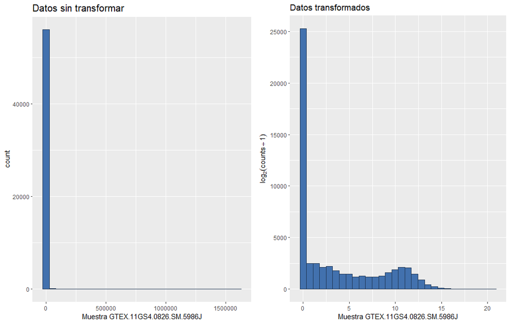

## 4.3 Opciones para estabilizar la varianza y PCA

Previo a un análisis de PCA, es conveniente controlar la varianza de la muestra, ya que funcionan mejor en situación cercana a la homocedasticidad. Esto puede suponer un problema en los recuentos de ARN-seq, pues la varianza esperada crece con la media. El paquete `DESeq2` ofrece dos transformaciones distintas:

- VST: Más rápida, pensada para conjunto de datos > 30 muestras
- Rlog: Más lento, pensado para conjunto de datos < 30 muestras

En común, ambas generan una información similar al log2 ordinario en recuentos normalizados pero no para recuentos más bajos. Además, ambas generan un objeto `DESeqTransform`. Procederemos a comparar los resultados de las tres transformaciones.

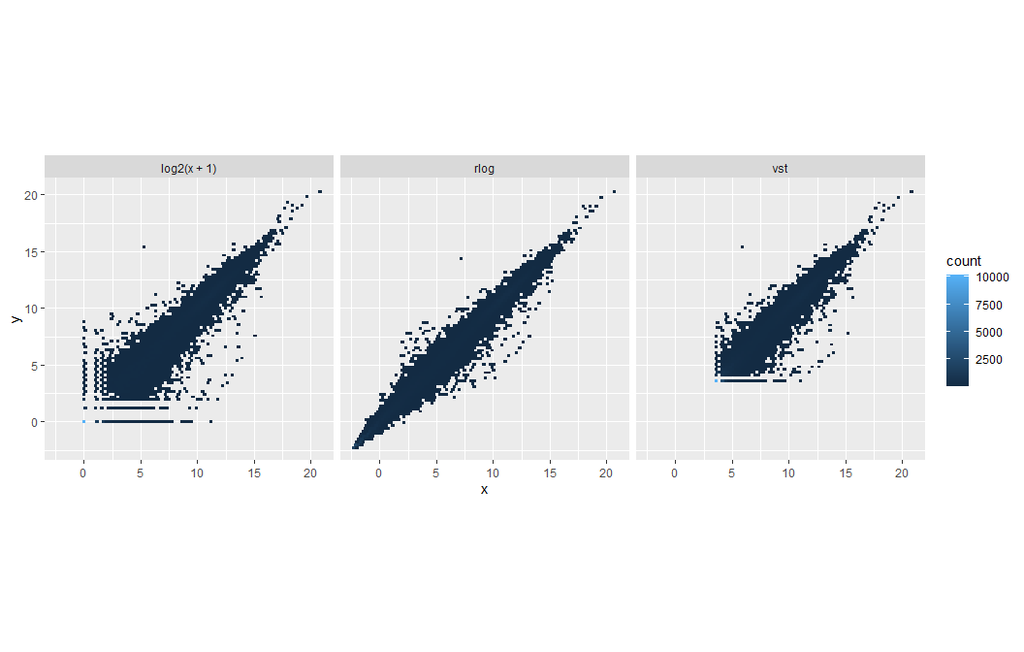

Por rapidez de las muestras, se trabajará con la transformación de la función `STV` al ser más rápida y nuestra muestra tener un tamaño intermedio. Esta transformación SOLO SE EMPLEARÁ PARA EL PCA. Según la información de vignettes del paquete `DESeq2` *“The variance stabilizing and rlog transformations are provided for applications other than differential testing, for example clustering of samples or other machine learning applications. For differential testing we recommend the DESeq function applied to raw counts.”*

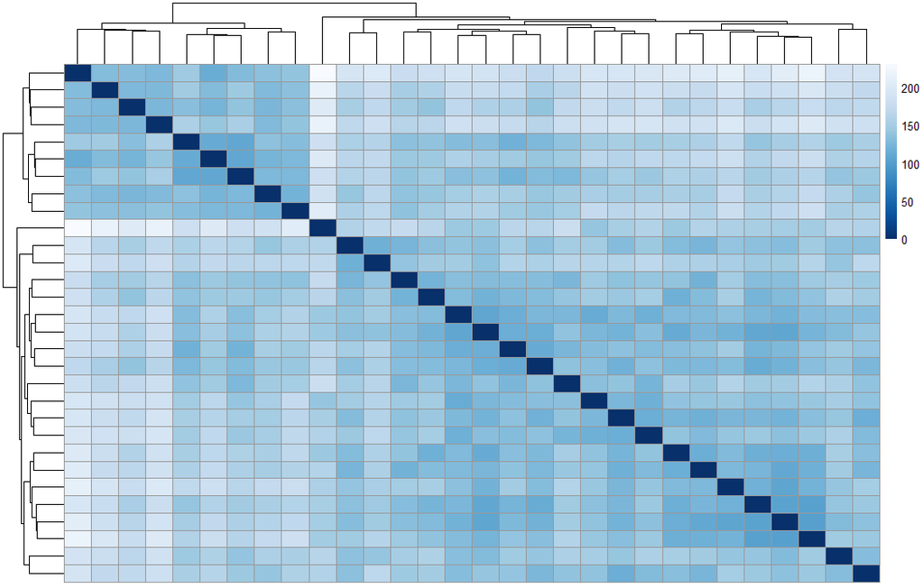

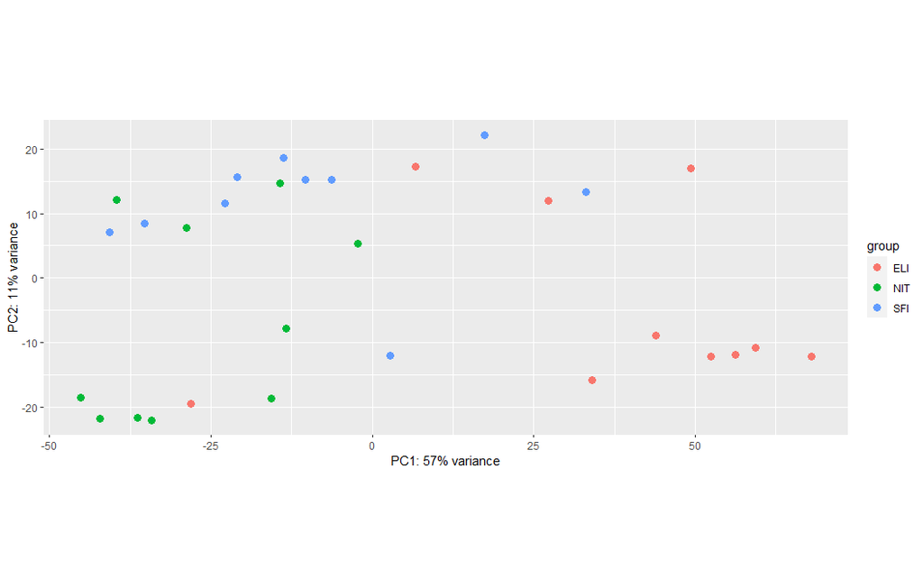

A simple vista no parece haber una separación completa de las muestras, pero los valores de ELI parecen estar en su mayoría separados por los valores positivos del PC1, mientras que existe cierta separación entre NIT y SFI en función del PC2. Esto podría sugerir realizar un análisis SFI & NIT vs ELI (sin infiltración o infiltración suave vs infiltración grave), este planteamiento tendría cierta lógica en cuanto a que desde que ocurre un evento hasta que se muestran cambios de expresión puede haber un desfase. Sin embargo, como no se especifica en el enunciado y este ejercicio busca simplemente trabajar con las herramientas más que sacar conclusiones de los datos, no se aplicará este enfoque.

## 4.4 Normalizar con DeSeq y expresión diferencial

El primer paso para normalizar nuestros datos pasa por ejecutar la función `DESeq()` sobre nuestro objeto de la clase `DESeqDataSet`. Esta función lleva a cabo un análisis que incluye los pasos de *estimation of size factors*, *estimation of dispersion* y *Negative Binomial GLM fitting and Wald statistics*, tal como se explica en su documentación y se muestra en el propio output de su llamada. Por tanto, partiremos de la versión del objeto `dds` con el que entramos al apartado anterior (dds2).

La función `results` que realiza el cálculo requiere el parámetro `contrast`, el cual SOLO ACEPTA DOS ELEMENTOS A COMPARAR. como tenemos tres grupos (NIT,SFI y ELI) se realizarán 3 pruebas:

- NS: NIT vs SFI
- NE: NIT vs ELI
- SE: SFI vs ELI

### 4.4.1 NIT vs SFI

A continuación, se muestran la información del objeto `DESeqResults`, tanto de las columnas que lo forman como de un sumario estadístico.

```
DataFrame with 6 rows and 2 columns
                       type                               description
                <character>                               <character>
baseMean       intermediate mean of normalized counts for all samples
log2FoldChange      results  log2 fold change (MLE): Group NIT vs SFI
lfcSE               results          standard error: Group NIT vs SFI
stat                results          Wald statistic: Group NIT vs SFI
pvalue              results       Wald test p-value: Group NIT vs SFI
padj                results                      BH adjusted p-values
```

```
out of 43484 with nonzero total read count
adjusted p-value < 0.1
LFC > 0 (up)       : 9, 0.021%
LFC < 0 (down)     : 23, 0.053%
outliers [1]       : 0, 0%
low counts [2]     : 16864, 39%
(mean count < 3)
[1] see 'cooksCutoff' argument of ?results
[2] see 'independentFiltering' argument of ?results
```

A partir de aquí se pueden representar el conjunto total de genes obtenidos en el análisis de expresión diferencial con un volcano plot. En este gráfico se han señalado los genes DE con un p.valor ajustado < 0.1 y un valor absoluto logFC > 2. Se ha elegido un valor de p.valor relativamente laxo ya que son muy pocos los genes diferencialmente expresados.

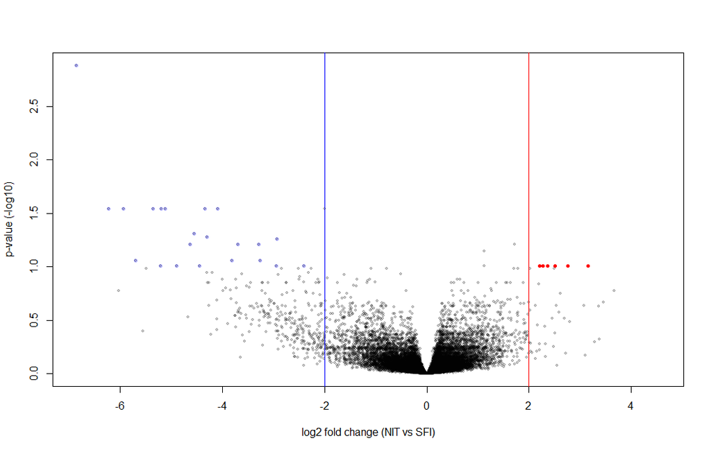

Con esta información podemos plantearnos qué genes concretos queremos ver (en algunos casos según muchos como para mostrarlos todos). En principio no aplicaremos filtro por *log2FoldChange*, pues cualquier efecto, por pequeño que sea, podría ser interesante introducirlo. Ya a posteriori el investigador que analice los resultados puede proponer un filtro más estricto y tener en cuenta solo aquellos que presenten un cambio drástico.

Muestra de algunos genes infraexpresados (genes_down)

|  | baseMean | log2FoldChange | lfcSE | stat | pvalue | padj |
| --- | --- | --- | --- | --- | --- | --- |
| ENSG00000211611 | 199.27766 | -6.861981 | 1.258049 | -5.454461 | 0.000000 | 0.001308 |
| ENSG00000242580 | 38.89787 | -6.228639 | 1.381366 | -4.509042 | 0.000007 | 0.028672 |
| ENSG00000225523 | 38.54765 | -5.944435 | 1.328526 | -4.474458 | 0.000008 | 0.028672 |
| ENSG00000254326 | 10.49534 | -5.695835 | 1.427501 | -3.990075 | 0.000066 | 0.087926 |
| ENSG00000211942 | 156.52457 | -5.362991 | 1.184488 | -4.527686 | 0.000006 | 0.028672 |
| ENSG00000235896 | 49.37072 | -5.212684 | 1.351490 | -3.856992 | 0.000115 | 0.098424 |

Muestra de algunos genes sobreexpresados (genes_up)

|  | baseMean | log2FoldChange | lfcSE | stat | pvalue | padj |
| --- | --- | --- | --- | --- | --- | --- |
| ENSG00000172137 | 26.948432 | 3.148595 | 0.796398 | 3.953545 | 0.000077 | 0.097620 |
| ENSG00000167588 | 670.376127 | 2.765102 | 0.707554 | 3.907971 | 0.000093 | 0.098424 |
| ENSG00000233680 | 25.242488 | 2.506758 | 0.641257 | 3.909134 | 0.000093 | 0.098424 |
| ENSG00000267596 | 6.357412 | 2.359998 | 0.611975 | 3.856362 | 0.000115 | 0.098424 |
| ENSG00000260545 | 8.908248 | 2.277670 | 0.583499 | 3.903472 | 0.000095 | 0.098424 |
| ENSG00000259453 | 6.042836 | 2.207857 | 0.573526 | 3.849618 | 0.000118 | 0.098424 |

Podrían aplicarse filtros más estrictos, como pueda ser bajar el *FDR* (False Discover Rate) o subiendo el *log2 fold change*. Como el número de genes expresados de forma diferencial es bastante bajo **(32 genes en total, 23 down y 9 up**) no vamos a aplicar nigún recorte.

Otra de las opciones a comentar es que existe un elevado número de *low counts*, por lo que se podrían repetir los resultados pasando el objeto dds por la función `lfcShrink()`. El objetivo de esto sería ajustar los *fold change* cuando el número de *reads* es bajo. Esta función utiliza la información de todos los genes para generar una estimación más precisa de dicho *fold change*, de modo que aquellos genes con poca información o dispersión alta vean reducido su *fold change* calculado. Para agilizar el proceso, tampoco va a aplicarse este enfoque, pero es conveniente comentar su existencia en caso de buscar un análisis más exhaustivo.

### 4.4.2 NIT vs ELI

A continuación, se muestran la información del objeto `DESeqResults`, tanto de las columnas que lo forman como de un sumario estadístico.

```
DataFrame with 6 rows and 2 columns
                       type                               description
                <character>                               <character>
baseMean       intermediate mean of normalized counts for all samples
log2FoldChange      results  log2 fold change (MLE): Group NIT vs ELI
lfcSE               results          standard error: Group NIT vs ELI
stat                results          Wald statistic: Group NIT vs ELI
pvalue              results       Wald test p-value: Group NIT vs ELI
padj                results                      BH adjusted p-values
```

```
out of 43484 with nonzero total read count
adjusted p-value < 0.1
LFC > 0 (up)       : 2286, 5.3%
LFC < 0 (down)     : 3808, 8.8%
outliers [1]       : 0, 0%
low counts [2]     : 12649, 29%
(mean count < 1)
[1] see 'cooksCutoff' argument of ?results
[2] see 'independentFiltering' argument of ?results
```

A partir de aquí se pueden representar el conjunto total de genes obtenidos en el análisis de expresión diferencial con un volcano plot. En este gráfico se han señalado los genes con un p.valor ajustado < 0.01 y un valor absoluto logFC > 2.

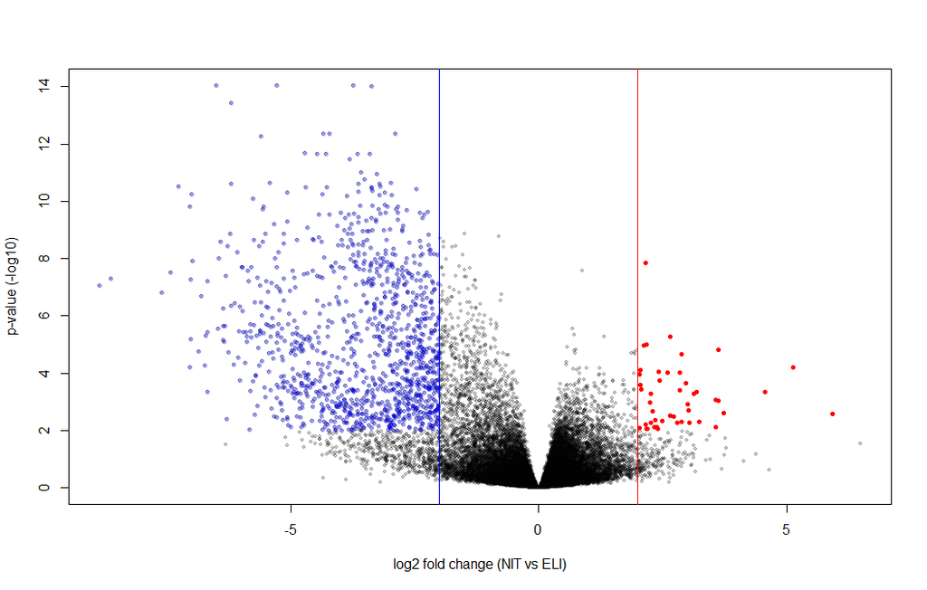

Con esta información podemos plantearnos qué genes concretos queremos ver (en algunos casos según muchos como para mostrarlos todos). En principio no aplicaremos filtro por *log2FoldChange*, pues cualquier efecto, por pequeño que sea, podría ser interesante introducirlo. Ya a posteriori el investigador que analice los resultados puede proponer un filtro más estricto y tener en cuenta solo aquellos que presenten un cambio drástico.

Muestra de algunos genes infraexpresados (genes_down)

|  | baseMean | log2FoldChange | lfcSE | stat | pvalue | padj |
| --- | --- | --- | --- | --- | --- | --- |
| ENSG00000170054 | 39.87466 | -8.859748 | 1.440348 | -6.151115 | 0 | 0 |
| ENSG00000242580 | 38.89787 | -8.622657 | 1.378414 | -6.255491 | 0 | 0 |
| ENSG00000211611 | 199.27766 | -7.607952 | 1.257944 | -6.047924 | 0 | 0 |
| ENSG00000253998 | 79.00985 | -7.426276 | 1.169393 | -6.350539 | 0 | 0 |
| ENSG00000211640 | 1032.76268 | -7.262727 | 0.953032 | -7.620652 | 0 | 0 |
| ENSG00000271046 | 34.33690 | -7.033675 | 0.959275 | -7.332282 | 0 | 0 |

Muestra de algunos genes sobreexpresados (genes_up)

|  | baseMean | log2FoldChange | lfcSE | stat | pvalue | padj |
| --- | --- | --- | --- | --- | --- | --- |
| ENSG00000110680 | 12988.051512 | 5.914071 | 1.561574 | 3.787249 | 0.000152 | 0.002552 |
| ENSG00000187288 | 401.584478 | 5.132310 | 1.075070 | 4.773933 | 0.000002 | 0.000064 |
| ENSG00000181092 | 541.973146 | 4.559666 | 1.066456 | 4.275530 | 0.000019 | 0.000458 |
| ENSG00000182583 | 2.046604 | 3.729317 | 0.980930 | 3.801819 | 0.000144 | 0.002432 |
| ENSG00000240975 | 11.233865 | 3.616357 | 0.885316 | 4.084819 | 0.000044 | 0.000927 |
| ENSG00000167588 | 670.376127 | 3.616065 | 0.708199 | 5.105999 | 0.000000 | 0.000015 |

Podrían aplicarse filtros más estrictos, como pueda ser bajar el *FDR* (False Discover Rate) o subiendo el *log2 fold change*. En este caso, se han detectado **2594 genes en total, 2081 down y 513 up**.

Otra de las opciones a comentar es que existe un elevado número de *low counts*, por lo que se podrían repetir los resultados pasando el objeto dds por la función `lfcShrink()`. El objetivo de esto sería ajustar los *fold change* cuando el número de *reads* es bajo. Esta función utiliza la información de todos los genes para generar una estimación más precisa de dicho *fold change*, de modo que aquellos genes con poca información o dispersión alta vean reducido su *fold change* calculado. Para agilizar el proceso, tampoco va a aplicarse este enfoque, pero es conveniente comentar su existencia en caso de buscar un análisis más exhaustivo.

### 4.4.3 SFI vs ELI

A continuación, se muestran la información del objeto `DESeqResults`, tanto de las columnas que lo forman como de un sumario estadístico.

```
DataFrame with 6 rows and 2 columns
                       type                               description
                <character>                               <character>
baseMean       intermediate mean of normalized counts for all samples
log2FoldChange      results  log2 fold change (MLE): Group SFI vs ELI
lfcSE               results          standard error: Group SFI vs ELI
stat                results          Wald statistic: Group SFI vs ELI
pvalue              results       Wald test p-value: Group SFI vs ELI
padj                results                      BH adjusted p-values
```

```
out of 43484 with nonzero total read count
adjusted p-value < 0.1
LFC > 0 (up)       : 1623, 3.7%
LFC < 0 (down)     : 3105, 7.1%
outliers [1]       : 0, 0%
low counts [2]     : 14335, 33%
(mean count < 1)
[1] see 'cooksCutoff' argument of ?results
[2] see 'independentFiltering' argument of ?results
```

A partir de aquí se pueden representar el conjunto total de genes obtenidos en el análisis de expresión diferencial con un volcano plot. En este gráfico se han señalado los genes con un p.valor ajustado < 0.01 y un valor absoluto logFC > 2.

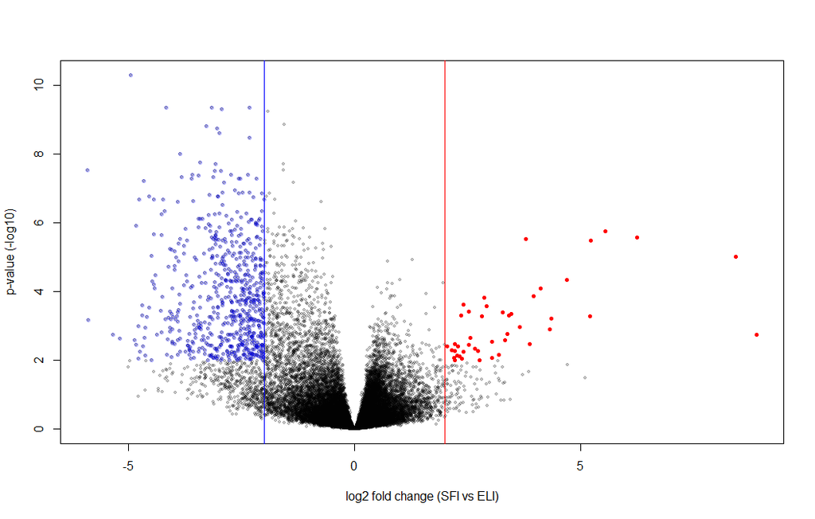

Con esta información podemos plantearnos qué genes concretos queremos ver (en algunos casos según muchos como para mostrarlos todos). En principio no aplicaremos filtro por *log2FoldChange*, pues cualquier efecto, por pequeño que sea, podría ser interesante introducirlo. Ya a posteriori el investigador que analice los resultados puede proponer un filtro más estricto y tener en cuenta solo aquellos que presenten un cambio drástico.

Muestra de algunos genes infraexpresados (genes_down)

|  | baseMean | log2FoldChange | lfcSE | stat | pvalue | padj |
| --- | --- | --- | --- | --- | --- | --- |
| ENSG00000248571 | 5.417151 | -5.909387 | 0.878447 | -6.727083 | 0.0e+00 | 0.000000 |
| ENSG00000211931 | 4.376983 | -5.889991 | 1.366813 | -4.309289 | 1.6e-05 | 0.000661 |
| ENSG00000253435 | 2.415983 | -5.341794 | 1.331110 | -4.013038 | 6.0e-05 | 0.001800 |
| ENSG00000231682 | 3.188469 | -5.191779 | 1.322050 | -3.927067 | 8.6e-05 | 0.002377 |
| ENSG00000143167 | 42.295637 | -4.952356 | 0.622344 | -7.957591 | 0.0e+00 | 0.000000 |
| ENSG00000253140 | 1.810527 | -4.862033 | 1.248570 | -3.894082 | 9.9e-05 | 0.002632 |

Muestra de algunos genes sobreexpresados (genes_up)

|  | baseMean | log2FoldChange | lfcSE | stat | pvalue | padj |
| --- | --- | --- | --- | --- | --- | --- |
| ENSG00000134443 | 170.36701 | 8.897457 | 2.215065 | 4.016793 | 5.9e-05 | 0.001784 |
| ENSG00000110680 | 12988.05151 | 8.436167 | 1.561563 | 5.402386 | 0.0e+00 | 0.000010 |
| ENSG00000100604 | 423.47677 | 6.236516 | 1.091576 | 5.713313 | 0.0e+00 | 0.000003 |
| ENSG00000128564 | 114.51864 | 5.537478 | 0.951642 | 5.818869 | 0.0e+00 | 0.000002 |
| ENSG00000157005 | 23.32345 | 5.215489 | 0.922613 | 5.652955 | 0.0e+00 | 0.000003 |
| ENSG00000105388 | 101.33248 | 5.210565 | 1.189938 | 4.378855 | 1.2e-05 | 0.000522 |

Podrían aplicarse filtros más estrictos, como pueda ser bajar el *FDR* (False Discover Rate) o subiendo el *log2 fold change*. En este caso, se han detectado **1706 genes en total, 1440 down y 266 up**.

Otra de las opciones a comentar es que existe un elevado número de *low counts*, por lo que se podrían repetir los resultados pasando el objeto dds por la función `lfcShrink()`. El objetivo de esto sería ajustar los *fold change* cuando el número de *reads* es bajo. Esta función utiliza la información de todos los genes para generar una estimación más precisa de dicho *fold change*, de modo que aquellos genes con poca información o dispersión alta vean reducido su *fold change* calculado. Para agilizar el proceso, tampoco va a aplicarse este enfoque, pero es conveniente comentar su existencia en caso de buscar un análisis más exhaustivo.

## 4.5 Anotación de genes

El primer paso para llevar a cabo el proceso de anotación de resultados consiste en identificar y cargar la librería con la base de datos que se corresponde con el genoma utilizado en nuestro estudio. En este caso se trata del hg18, pero como quiera que los identificadores ENSG son estables, es posible trabajar con el paquete `org.Hs.eg.db` correspondiente al organismo *Homo sapiens* (`Hs`) y *Entrez gene ids* (`eg`).

Por algún motivo, existe una gran cantidad de datos que no existen en el paquete; 31704 ausentes frente a 24498 presentes. Por esto las tablas que se muestran serán, ordenadas por la magnitud de efecto, las primeras que tengan asociación.

### 4.5.1 NIT vs SFI

```
 [1] "ACCNUM"       "ALIAS"        "ENSEMBL"      "ENSEMBLPROT"  "ENSEMBLTRANS"
 [6] "ENTREZID"     "ENZYME"       "EVIDENCE"     "EVIDENCEALL"  "GENENAME"
[11] "GO"           "GOALL"        "IPI"          "MAP"          "OMIM"
[16] "ONTOLOGY"     "ONTOLOGYALL"  "PATH"         "PFAM"         "PMID"
[21] "PROSITE"      "REFSEQ"       "SYMBOL"       "UCSCKG"       "UNIGENE"
[26] "UNIPROT"
```

Muestra de algunos genes sobreexpresados (genes_up)

|  | ENSEMBL | SYMBOL | GENENAME | ENTREZID |
| --- | --- | --- | --- | --- |
| 1 | ENSG00000172137 | CALB2 | calbindin 2 | 794 |
| 2 | ENSG00000167588 | GPD1 | glycerol-3-phosphate dehydrogenase 1 | 2819 |
| 7 | ENSG00000255585 | LOC651337 | uncharacterized LOC651337 | 651337 |
| 9 | ENSG00000203865 | ATP1A1-AS1 | ATP1A1 antisense RNA 1 | 84852 |

Muestra de algunos genes infraexpresados (genes_down)

|  | ENSEMBL | SYMBOL | GENENAME | ENTREZID |
| --- | --- | --- | --- | --- |
| 15 | ENSG00000157005 | SST | somatostatin | 6750 |
| 20 | ENSG00000170476 | MZB1 | marginal zone B and B1 cell specific protein | 51237 |
| 22 | ENSG00000130643 | CALY | calcyon neuron specific vesicular protein | 50632 |

### 4.5.2 NIT vs ELI

```
 [1] "ACCNUM"       "ALIAS"        "ENSEMBL"      "ENSEMBLPROT"  "ENSEMBLTRANS"
 [6] "ENTREZID"     "ENZYME"       "EVIDENCE"     "EVIDENCEALL"  "GENENAME"
[11] "GO"           "GOALL"        "IPI"          "MAP"          "OMIM"
[16] "ONTOLOGY"     "ONTOLOGYALL"  "PATH"         "PFAM"         "PMID"
[21] "PROSITE"      "REFSEQ"       "SYMBOL"       "UCSCKG"       "UNIGENE"
[26] "UNIPROT"
```

Muestra de algunos genes sobreexpresados (genes_up)

|  | ENSEMBL | SYMBOL | GENENAME | ENTREZID |
| --- | --- | --- | --- | --- |
| 1 | ENSG00000110680 | CALCA | calcitonin related polypeptide alpha | 796 |
| 2 | ENSG00000187288 | CIDEC | cell death inducing DFFA like effector c | 63924 |
| 3 | ENSG00000181092 | ADIPOQ | adiponectin, C1Q and collagen domain containing | 9370 |
| 4 | ENSG00000182583 | VCX | variable charge X-linked | 26609 |
| 6 | ENSG00000167588 | GPD1 | glycerol-3-phosphate dehydrogenase 1 | 2819 |
| 7 | ENSG00000184811 | TRARG1 | trafficking regulator of GLUT4 (SLC2A4) 1 | 286753 |

Muestra de algunos genes infraexpresados (genes_down)

|  | ENSEMBL | SYMBOL | GENENAME | ENTREZID |
| --- | --- | --- | --- | --- |
| 1 | ENSG00000170054 | SERPINA9 | serpin family A member 9 | 327657 |
| 15 | ENSG00000235304 | LINC01281 | long intergenic non-protein coding RNA 1281 | 286442 |
| 21 | ENSG00000177455 | CD19 | CD19 molecule | 930 |
| 22 | ENSG00000164362 | TERT | telomerase reverse transcriptase | 7015 |
| 26 | ENSG00000197549 | PRAMENP | PRAME N-terminal like, pseudogene | 649179 |
| 34 | ENSG00000143297 | FCRL5 | Fc receptor like 5 | 83416 |

### 4.5.3 SFI vs ELI

```
 [1] "ACCNUM"       "ALIAS"        "ENSEMBL"      "ENSEMBLPROT"  "ENSEMBLTRANS"
 [6] "ENTREZID"     "ENZYME"       "EVIDENCE"     "EVIDENCEALL"  "GENENAME"
[11] "GO"           "GOALL"        "IPI"          "MAP"          "OMIM"
[16] "ONTOLOGY"     "ONTOLOGYALL"  "PATH"         "PFAM"         "PMID"
[21] "PROSITE"      "REFSEQ"       "SYMBOL"       "UCSCKG"       "UNIGENE"
[26] "UNIPROT"
```

Muestra de algunos genes sobreexpresados (genes_up)

| ENSEMBL | SYMBOL | GENENAME | ENTREZID |
| --- | --- | --- | --- |
| ENSG00000134443 | GRP | gastrin releasing peptide | 2922 |
| ENSG00000110680 | CALCA | calcitonin related polypeptide alpha | 796 |
| ENSG00000100604 | CHGA | chromogranin A | 1113 |
| ENSG00000128564 | VGF | VGF nerve growth factor inducible | 7425 |
| ENSG00000157005 | SST | somatostatin | 6750 |
| ENSG00000105388 | CEACAM5 | CEA cell adhesion molecule 5 | 1048 |

Muestra de algunos genes infraexpresados (genes_down)

|  | ENSEMBL | SYMBOL | GENENAME | ENTREZID |
| --- | --- | --- | --- | --- |
| 4 | ENSG00000231682 | LINC01891 | long intergenic non-protein coding RNA 1891 | 105373934 |
| 5 | ENSG00000143167 | GPA33 | glycoprotein A33 | 10223 |
| 9 | ENSG00000197549 | PRAMENP | PRAME N-terminal like, pseudogene | 649179 |
| 10 | ENSG00000111536 | IL26 | interleukin 26 | 55801 |
| 11 | ENSG00000127074 | RGS13 | regulator of G protein signaling 13 | 6003 |
| 12 | ENSG00000170054 | SERPINA9 | serpin family A member 9 | 327657 |

## 4.6 Análisis de significación biológica

En este análisis de significación biológica se ha utilizado GO BP (gene ontology, biological process) para el conjunto de genes obtenidos en DESeq2.

- El primer gráfico ilustrará las funciones genéricas en las que participan el conjunto de genes.
- El segundo y el tercero serán representación de los procesos biológicos específicos en los que participa este conjunto.

Por cada comparación, tendremos DOS grupos, los up-regulated y los down-regulated.

### 4.6.1 NIT vs SFI

#### 4.6.1.1 Up-regulated

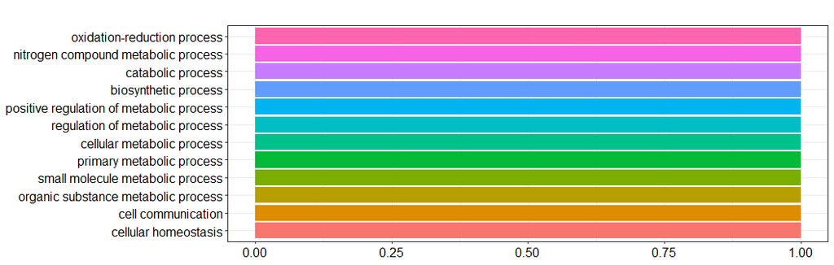

Gráfico de barras con las funciones genéricas sobreexpresadas en NIT vs SFI con groupGO().

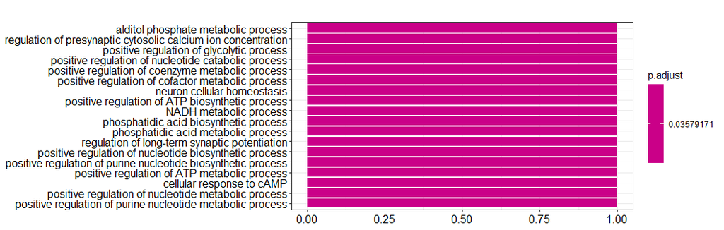

Gráfico de barras con las funciones genéricas sobreexpresadas en NIT vs SFI con enrichGO().

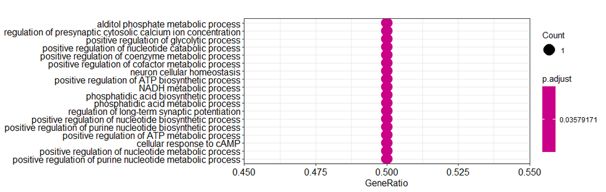

Gráfico de puntos con las funciones genéricas sobreexpresadas en NIT vs SFI con enrichGO().

#### 4.6.1.2 Down-regulated

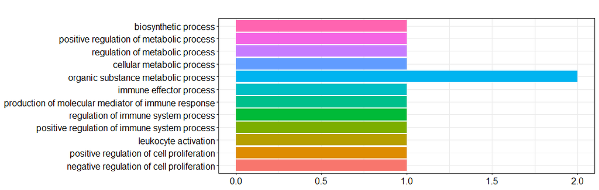

Gráfico de barras con las funciones genéricas infraexpresadas en NIT vs SFI con groupGO().

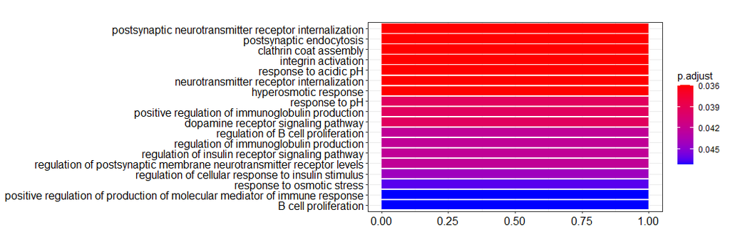

Gráfico de barras con las funciones genéricas infraexpresadas en NIT vs SFI con enrichGO().

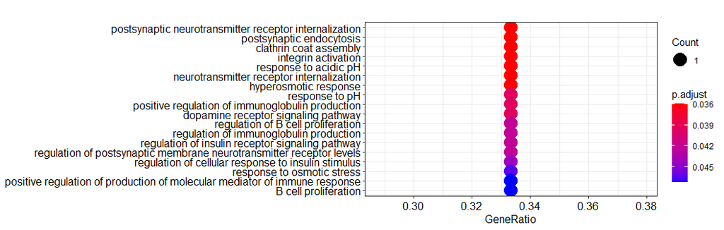

Gráfico de puntos con las funciones genéricas infraexpresadas en NIT vs SFI con enrichGO().

### 4.6.2 NIT vs ELI

#### 4.6.2.1 Up-regulated

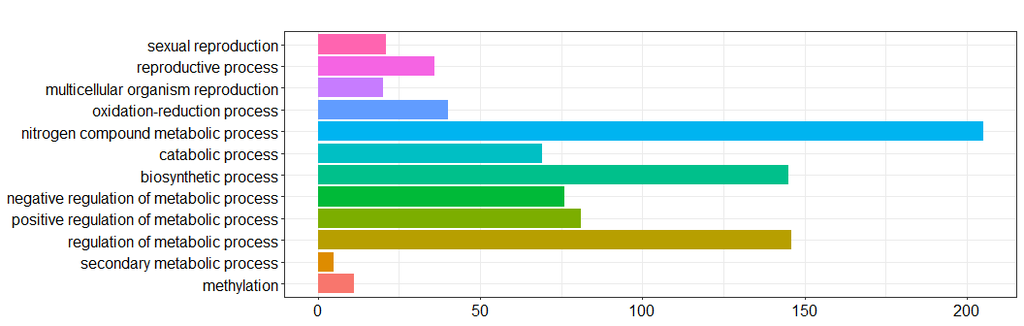

Gráfico de barras con las funciones genéricas sobreexpresadas en NIT vs ELI con groupGO().

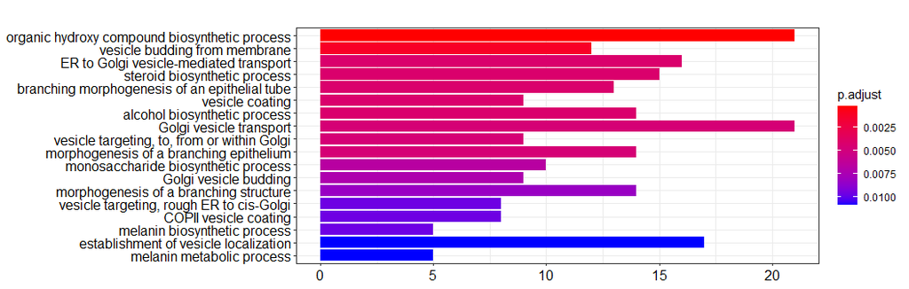

Gráfico de barras con las funciones genéricas sobreexpresadas en NIT vs ELI con enrichGO().

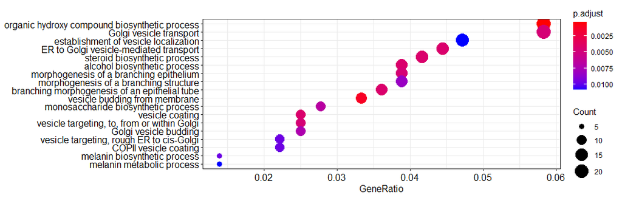

Gráfico de puntos con las funciones genéricas sobreexpresadas en NIT vs ELI con enrichGO().

#### 4.6.2.2 Down-regulated

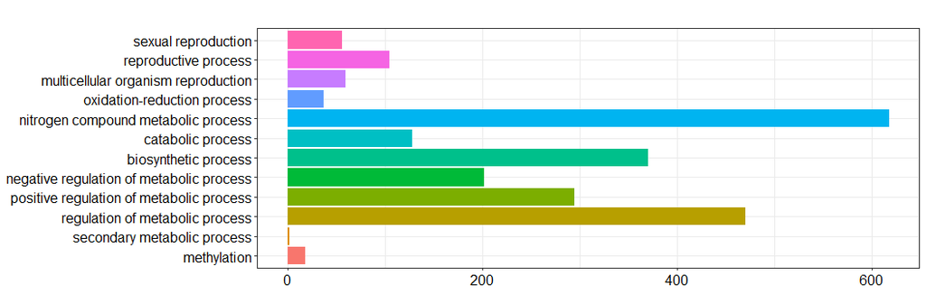

Gráfico de barras con las funciones genéricas infraexpresadas en NIT vs ELI con groupGO().

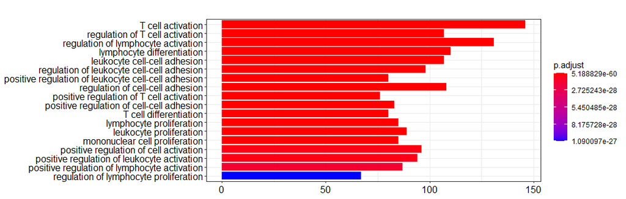

Gráfico de barras con las funciones genéricas infraexpresadas en NIT vs ELI con enrichGO().

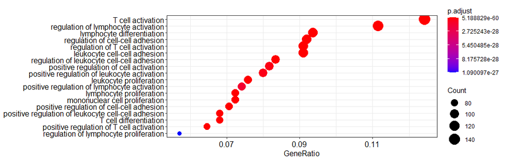

Gráfico de puntos con las funciones genéricas infraexpresadas en NIT vs ELI con enrichGO().

### 4.6.3 SFI vs ELI

#### 4.6.3.1 Up-regulated

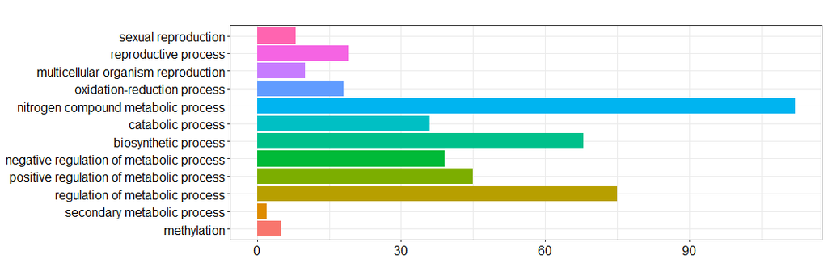

Gráfico de barras con las funciones genéricas sobreexpresadas en SFI vs ELI con groupGO().

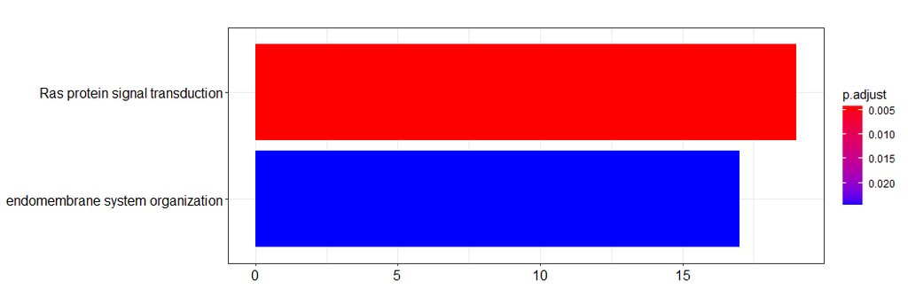

Gráfico de barras con las funciones genéricas sobreexpresadas en SFI vs ELI con enrichGO().

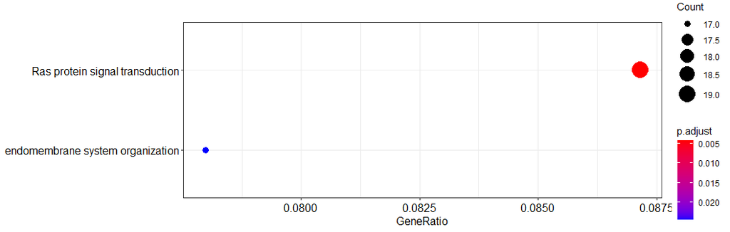

Gráfico de puntos con las funciones genéricas sobreexpresadas en SFI vs ELI con enrichGO().

#### 4.6.3.2 Down-regulated

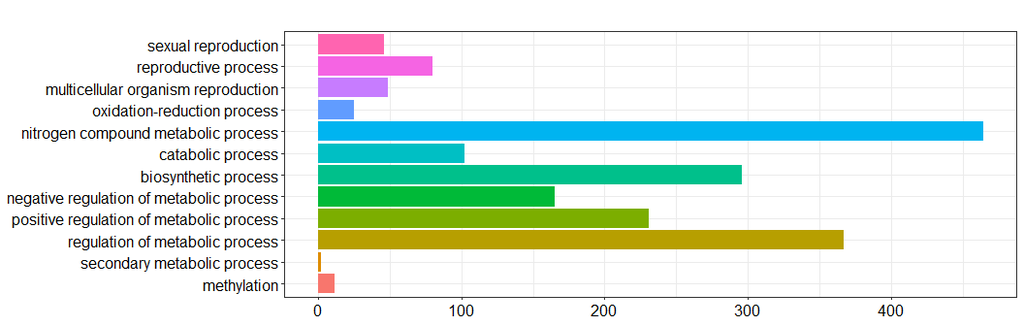

Gráfico de barras con las funciones genéricas infraexpresadas en SFI vs ELI con groupGO().

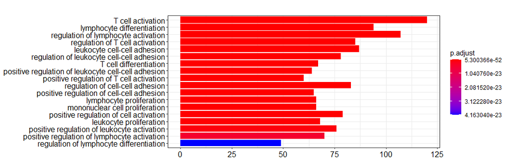

Gráfico de barras con las funciones genéricas infraexpresadas en SFI vs ELI con enrichGO().

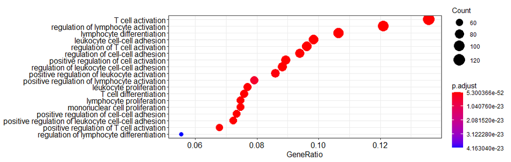

Gráfico de puntos con las funciones genéricas infraexpresadas en SFI vs ELI con enrichGO().

# 5 Discusión

## 5.2 Puntos a mejorar/modificar

Existen algunas mejoras/modificaciones que sería interesante comentar. Algunas de ellas ya han sido comentadas en sus correspondientes apartados, pero considero de interés mostrarlas agrupadas por tener un enfoque general de los cambios que podrían realizarse.

- **Tener el artículo original**: Al no tener el origen de los datos, resulta difícil tomar decisiones tanto por no saber por dónde enfocar el análisis como no saber qué buscan los investigadores con estos datos. Un ejemplo de esto sería que, en la tabla targets, la variable `molecular_data_type` presenta como opciones Allele-Specific Expression y RNA Seq (NGS), pero ninguna de las dos tiene muestra suficiente para tomar una sola en el estudio, por lo que, ante la duda de cuál de los dos tomar, se ha decidido usarlas de forma indistinta.
- **Parámetros de filtro**: Podrían filtrarse los p-valor ajustados o los logFC según se quiera un análisis más o menos laxo.
- **Función lfcShrink()**: En los cálculos de expresión diferencial de genes, no altera la cantidad de genes detectados, pero sí ajusta el logFC de aquellos con conteos bajos. No se ha aplicado, pero podría ser interesante una comparación entre llevar o no a cabo esta función.
- **La unión hace la fuerza**: Existen múltiples paquetes de R que permiten identificar qué genes están expresados de forma diferencial entre dos conjuntos de muestra. En este caso se han empleado las herramientas del paquete `DESeq`, pero otra posibilidad habría sido `edgeR`. Se podría plantear, para un estudio muy restrictivo, el uso de ambas y tomar solo los genes que resulten efectivos en ambas, siendo estos más seguros por tener dos evidencias que los señalan.
- **Análisis NIT & SFI vs ELI**: La falta de diferencias significativas entre estas dos muestras, podrían plantear un análisis conjunto de estas muestras frente al otro grupo.
- **NA en anotaciones**: Parece ser que cerca de la mitad de los genes analizados no estaban presentes en la el paquete empleado para asociar las anotaciones. Podría ser un problema de la nomenclatura de la muestra o podría plantearse utilizar otro paquete que pudiese recoger mejor el total de información.
- **Exportación de datos**: Se ha generado gran cantidad de tablas, en algún momento podría ser interesante exportar alguna de la información recogida para tener un listado extenso (Como podría ser recoger en un Excel la información de los genes up-regulated entre NIT y ELI).